# Другая Роза

Письма Розы Люксембург  
в переводе Маргариты Школьниксон-Смишко

Автор

Анастасия Богданова

Дата публикации

22.12.2024

Аннотация

Письма — больше чем воспоминания, на них запеклась кровь событий, это — само прошедшее, как оно было, задержанное и нетленное. (*А.И. Герцен. Былое и думы.*)

## «Красная Роза»

В своей работе я хотела проанализировать перевод пятитомного сборника писем **Розы Люксембург**, выполненный 2014-2015 годах *Маргаритой Школьниксон-Смишко* и опубликованный на сайте [proza.ru](https://proza.ru/avtor/cnamibog)

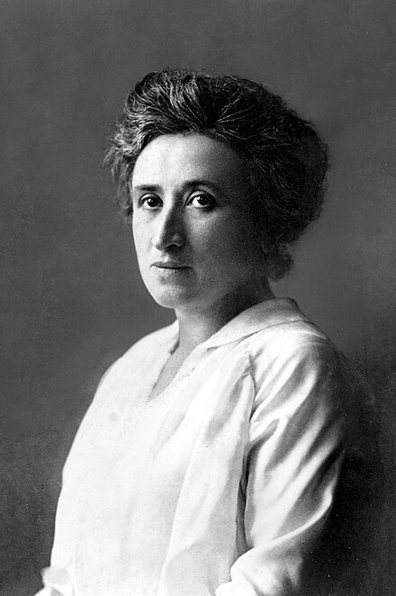

> **Роза Люксембург** *(имя при рождении Rosalia Luxenburg),* 5 марта 1871 — 15 января 1919.  
> Имя Розы Люксембург, великой революционерки-интернационалистки, широко известно. В нашей стране оно увековечено в названиях улиц, площадей, клубов, фабрик, учреждений во многих городах. Имя знают, но кем она была и чем занималась, понимает далеко не каждый.  
> Жизнь Розы Люксембург связана с социал-демократическим движением Польши, России и Германии. Она последовательно отстаивала принципы интернационализма в рабочем движении, выступала против милитаризма и войны. Несколько лет провела в тюрьмах. Принимала активное участие в Ноябрьской революции 1918 г. в Германии.  
> Вместе с Карлом Либкнехтом была убита в январе 1919 г.

## Luxemburg R. Gesammelte Briefe

Письма Розы Люксембург публиковались с 1982 по 1993 годы в немецком издательстве [DIETZBERLIN](https://dietzberlin.de/)[3].

[figure not shown]

Обложка одного из томов издания

[В томах с 1 по 6](https://dietzberlin.de/produkt/gesammelte-briefe-gesammelte-briefe-band-1-6/) собрано более 2700 писем, открыток и телеграмм более чем 150 корреспондентам в Европе и Америке.

В «Сборнике писем» представлены все сохранившиеся письма Розы Люксембург деятелям, которые были активными участниками немецкого рабочего движения или были связаны с ним, и которые доступны редакции.

## Содержание

- *Том 1* содержит письма Лео Йогихесу, Августу Бебелю, Карлу Каутскому, Минне Каутской, Францу и Еве Меринг, Паулю Лёбе, Роберту и Матильде Зейдель, Кларе Цеткин, Эмилю Эйххорну и Адольфу Гофману за период с 1893 по 1902 год.
- *Том 2* содержит письма Карлу Каутскому, Луизе Каутской, Лео Йогихесу, Вильгельму Дитману, Францу Мерингу, Юлиусу Брюнсу, Роберту Зайделю, Артуру Штадтхагену, Курту Эйснеру, Кларе Цеткин, Косте Цеткину, Фридриху Вестмейеру за период с 1903 по 1908 год.
- *Том 3* содержит письма Кларе Цеткин, Косте Цеткину, Конраду Хэнишу, Луизе Каутской, Гансу Каутскому, Лео Йогихесу, Паулю Лёбе, Марии Гек, Бранделю Гек, Паулю Леншу, Роберту и Матильде Зейдель за период с 1909 по 1910 год.
- *Том 4* содержит письма Францу Мерингу, Вильгельму Диттману, Бранделю Геку, Конраду Хэнишу, Лео Йогихесу, Луизе Каутской, Вальтеру Стоккеру, Фридриху Вестмейеру, Кларе Цеткин, Косте Цеткину, Гертруде Злотко, Юлиану Мархлевскому за период с 1911 по июль 1914 года.
- *Том 5* содержит письма Карлу Либкнехту, Софи Либкнехт, Гансу Дифенбаху, Матильде Якоб, Луизе Каутской, Францу Мерингу, Марте Розенбаум, Матильде Вурм, Кларе Цеткин, Косте Цеткин, Эрнсту Мейеру, Гертруде Злоттко, Фанни Езерской за период с августа 1914 года по январь. 1919.
- *Том 6* содержит письма Генриетте Роланд Хост, Карлу Радеку, Борису Кричевскому, Йозефу Блоху, Цезарине Войнаровской, Александру Потресову, Луису Будену, Павлу Аксельроду, Адольфу Варскому, Александру Богданову, Паулю Леви, Марии и Адольфу Гек, Косте Цеткину с 1891 по 1918 год.

Перевода сборника писем на русский язык не существует, оригинальный немецкий текст в свободный доступ не выложен. В фондах библиотеки Центра социально-политической истории ГПИБ России (ЦСПИ) имеются 5 первых томов издания. Стоимость [шеститомного сборника](https://dietzberlin.de/produkt/gesammelte-briefe-gesammelte-briefe-band-1-6/) на сайте издательства https://dietzberlin.de/ составляет на сегодняшний день 299,40 евро.

В 2014-2015 годах *Маргаритой Школьниксон-Смишко* был сделан любительский перевод части писем Розы Люксембург по имеющемуся у нее пятитомному изданию сборника (шестого тома и у нее не было). 184 небольшие повести или миниатюры, как классифицировал их автор, были опубликованы на сайте [proza.ru](https://proza.ru/avtor/cnamibog&s=0&book=45#45), 50 первых из них легли в основу настоящего исследования. Это не перевод в классическом понимании этого слова, в тексте нет точных указаний на номера томов и страниц. Вот как описывает автор свой замысел:

> Сначала я хотела перевести только некоторые особенно понравившиеся письма, но со временем их становилось всё больше, я погрузилась в ту эпоху, и у меня возникла мысль написать о Розе документальную повесть в письмах. О ней уже есть биографическая книга польского автора, но в ней был сделан совсем другой акцент. Хотя о Розе невозможно рассказывать без учёта её участия в политике, стремления изменить общество к лучшему, я постараюсь свести такие сведения к минимуму. Для меня Роза в первую очередь неординарная женщина, о ней и будет повесть.

При подготовке исследования были использованы и другие труды, посвященные Розе Люксембург, ее современникам и соратникам. [1] [2]

[output not shown]

## использованная литература

1. Роза Люксембург: Актуальные аспекты политической и научной деятельности (К 85-летию со дня гибели): Международная конференция в Москве 12 февраля 2004 г. Москва: Памятники исторической мысли, 2004. 294 c.

2. Миллер С., Поттхофф Х. Краткая история СДПГ. 1848-1990. / С. Миллер, Х. Поттхофф, Москва: Памятники исторической мысли, 1999. 344 c.

3. Luxemburg R. Gesammelte Briefe [Collected Letters] / R. Luxemburg, под ред. A. Laschitza, Berlin: Dietz Verlag, 1984.